# WerdenEtAl2019_Analysis

### Calculate randomized seed limitation means and 95% CIs for each species X treatment combination

```r
##### for controls (natural regeneration)
RANDO_C_df <- melt(RANDO_C) # convert list of random samples to long df
colnames(RANDO_C_df) <- c("sample", "iteration", "numberSeeds", "spp") # name columns

# THIS IS WHERE YOU NEED SCALING UPDATES, THEN SUMMARIES WORK TO MAKE FIG 2, OR NEED MORE CHANGES???

# calculate randomized seed limitation for each of the 1,000 iterations for species
randomSeedLimitation_calcs_C <- RANDO_C_df %>%
                                mutate(present = ifelse(numberSeeds>0, 1, 0)) %>%
                                group_by(spp, iteration) %>%
                                summarize(randomSeedLimitation = 1-(sum(present)/max(sample)))

# summarize and calculate 95% CIs
randomSeedLimitation_summary_C <- randomSeedLimitation_calcs_C %>%
                                    group_by(spp) %>%
                                    summarize(randomSeedLimitation_mean_C = mean(randomSeedLimitation, na.rm = TRUE),
                                              sd = sd(randomSeedLimitation, na.rm = TRUE),
                                              n = n()) %>%
                                    mutate(se = sd / sqrt(n),
                                           lower.ci = randomSeedLimitation_mean_C - qt(1 - (0.05 / 2), n - 1) * se,
                                           upper.ci = randomSeedLimitation_mean_C + qt(1 - (0.05 / 2), n - 1) * se)

randomSeedLimitation_summary_C$spp <- as.factor(randomSeedLimitation_summary_C$spp)
names (randomSeedLimitation_summary_C)[1] <- "Species"


# now compare observed to expected seed limitation
# select just the species you have observed seed limitation calculations for
seedsAndSeedlings_all_C <- seedRain_seedLimitationCalcs_trap[seedRain_seedLimitationCalcs_trap$Treatment == "C",]
seedsAndSeedlings_all_C<- seedsAndSeedlings_all_C[complete.cases(seedsAndSeedlings_all_C[ , 5]),]

# combine with random seed limitation
observedRandomCompare_seedLimitation_C <- inner_join(seedsAndSeedlings_all_C, randomSeedLimitation_summary_C, by = "Species")
observedRandomCompare_seedLimitation_C_final <- observedRandomCompare_seedLimitation_C[,c("Treatment", "Species", "seedLimitation", "randomSeedLimitation_mean_C", "lower.ci", "upper.ci")]

observedRandomCompare_seedLimitation_C_final <- observedRandomCompare_seedLimitation_C_final %>%
                                                mutate(deltaSeedLimitation_C = seedLimitation-randomSeedLimitation_mean_C)

#--------
##### for islands (applied nucleation)
RANDO_I_df <- melt(RANDO_I) # convert list of random samples to long df
colnames(RANDO_I_df) <- c("sample", "iteration", "numberSeeds", "spp") # name columns

# calculate randomized seed limitation for each of the 1,000 iterations for species
randomSeedLimitation_calcs_I <- RANDO_I_df %>%
                                mutate(present = ifelse(numberSeeds>0, 1, 0)) %>%
                                group_by(spp, iteration) %>%
                                summarize(randomSeedLimitation = 1-(sum(present)/max(sample)))

# summarize and calculate 95% CIs
randomSeedLimitation_summary_I <- randomSeedLimitation_calcs_I %>%
                                    group_by(spp) %>%
                                    summarize(randomSeedLimitation_mean_I = mean(randomSeedLimitation, na.rm = TRUE),
                                              sd = sd(randomSeedLimitation, na.rm = TRUE),
                                              n = n()) %>%
                                    mutate(se = sd / sqrt(n),
                                           lower.ci = randomSeedLimitation_mean_I - qt(1 - (0.05 / 2), n - 1) * se,
                                           upper.ci = randomSeedLimitation_mean_I + qt(1 - (0.05 / 2), n - 1) * se)

randomSeedLimitation_summary_I$spp <- as.factor(randomSeedLimitation_summary_I$spp)
names (randomSeedLimitation_summary_I)[1] <- "Species"


# now compare observed to expected seed limitation
# get just the species you have observed seed limitation values for
seedsAndSeedlings_all_I <- seedRain_seedLimitationCalcs_trap[seedRain_seedLimitationCalcs_trap$Treatment == "I",]
seedsAndSeedlings_all_I<- seedsAndSeedlings_all_I[complete.cases(seedsAndSeedlings_all_I[ , 5]),]

# combine with random seed limitation
observedRandomCompare_seedLimitation_I <- inner_join(seedsAndSeedlings_all_I, randomSeedLimitation_summary_I, by = "Species")
observedRandomCompare_seedLimitation_I_final <- observedRandomCompare_seedLimitation_I[,c("Treatment", "Species", "seedLimitation", "randomSeedLimitation_mean_I", "lower.ci", "upper.ci")]

observedRandomCompare_seedLimitation_I_final <- observedRandomCompare_seedLimitation_I_final %>%
                                              mutate(deltaSeedLimitation_I = seedLimitation-randomSeedLimitation_mean_I)


#--------
##### for plantations
RANDO_P_df <- melt(RANDO_P) # convert list of random samples to long df
colnames(RANDO_P_df) <- c("sample", "iteration", "numberSeeds", "spp") # name columns

# calculate randomized seed limitation for each of the 1,000 iterations for species
randomSeedLimitation_calcs_P <- RANDO_P_df %>%
                                mutate(present = ifelse(numberSeeds>0, 1, 0)) %>%
                                group_by(spp, iteration) %>%
                                summarize(randomSeedLimitation = 1-(sum(present)/max(sample)))

# summarize and calculate 95% CIs
randomSeedLimitation_summary_P <- randomSeedLimitation_calcs_P %>%
                                    group_by(spp) %>%
                                    summarize(randomSeedLimitation_mean_P = mean(randomSeedLimitation, na.rm = TRUE),
                                              sd = sd(randomSeedLimitation, na.rm = TRUE),
                                              n = n()) %>%
                                    mutate(se = sd / sqrt(n),
                                           lower.ci = randomSeedLimitation_mean_P - qt(1 - (0.05 / 2), n - 1) * se,
                                           upper.ci = randomSeedLimitation_mean_P + qt(1 - (0.05 / 2), n - 1) * se)

randomSeedLimitation_summary_P$spp <- as.factor(randomSeedLimitation_summary_P$spp)
names (randomSeedLimitation_summary_P)[1] <- "Species"

# now compare observed to expected seed limitation
# get just the species you have observed seed limitation values for
seedsAndSeedlings_all_P <- seedRain_seedLimitationCalcs_trap[seedRain_seedLimitationCalcs_trap$Treatment == "P",]
seedsAndSeedlings_all_P<- seedsAndSeedlings_all_P[complete.cases(seedsAndSeedlings_all_P[ , 5]),]

# combine with random seed limitation
observedRandomCompare_seedLimitation_P <- inner_join(seedsAndSeedlings_all_P, randomSeedLimitation_summary_P, by = "Species")
observedRandomCompare_seedLimitation_P_final <- observedRandomCompare_seedLimitation_P[,c("Treatment", "Species", "seedLimitation", "randomSeedLimitation_mean_P", "lower.ci", "upper.ci")]

observedRandomCompare_seedLimitation_P_final <- observedRandomCompare_seedLimitation_P_final %>%
                                              mutate(deltaSeedLimitation_P = seedLimitation-randomSeedLimitation_mean_P)


#--------
##### for reference
RANDO_R_df <- melt(RANDO_R) # convert list of random samples to long df
colnames(RANDO_R_df) <- c("sample", "iteration", "numberSeeds", "spp") # name columns

# calculate randomized seed limitation for each of the 1,000 iterations for species
randomSeedLimitation_calcs_R <- RANDO_R_df %>%
                                mutate(present = ifelse(numberSeeds>0, 1, 0)) %>%
                                group_by(spp, iteration) %>%
                                summarize(randomSeedLimitation = 1-(sum(present)/max(sample)))

# summarize and calculate 95% CIs
randomSeedLimitation_summary_R <- randomSeedLimitation_calcs_R %>%
                                    group_by(spp) %>%
                                    summarize(randomSeedLimitation_mean_R = mean(randomSeedLimitation, na.rm = TRUE),
                                              sd = sd(randomSeedLimitation, na.rm = TRUE),
                                              n = n()) %>%
                                    mutate(se = sd / sqrt(n),
                                           lower.ci = randomSeedLimitation_mean_R - qt(1 - (0.05 / 2), n - 1) * se,
                                           upper.ci = randomSeedLimitation_mean_R + qt(1 - (0.05 / 2), n - 1) * se)

randomSeedLimitation_summary_R$spp <- as.factor(randomSeedLimitation_summary_R$spp)
names (randomSeedLimitation_summary_R)[1] <- "Species"


# now compare observed to expected seed limitation
# get just the species you have observed seed limitation values for
seedsAndSeedlings_all_R <- seedRain_seedLimitationCalcs_trap[seedRain_seedLimitationCalcs_trap$Treatment == "R",]
seedsAndSeedlings_all_R<- seedsAndSeedlings_all_R[complete.cases(seedsAndSeedlings_all_R[ , 5]),]

# combine with random seed limitation
observedRandomCompare_seedLimitation_R <- inner_join(seedsAndSeedlings_all_R, randomSeedLimitation_summary_R, by = "Species")
observedRandomCompare_seedLimitation_R_final <- observedRandomCompare_seedLimitation_R[,c("Treatment", "Species", "seedLimitation", "randomSeedLimitation_mean_R", "lower.ci", "upper.ci")]

observedRandomCompare_seedLimitation_R_final <- observedRandomCompare_seedLimitation_R_final %>%
                                              mutate(deltaSeedLimitation_R = seedLimitation-randomSeedLimitation_mean_R)
```

### Make Table S3 which summarizes the observed and expected (from randomization) seed limitation

```r
# rename  columns for comparisons
names(observedRandomCompare_seedLimitation_C_final)[3] <- "seedLimitation_observed_C"
names(observedRandomCompare_seedLimitation_C_final)[5] <- "lower.ci.C"
names(observedRandomCompare_seedLimitation_C_final)[6] <- "upper.ci.C"
names(observedRandomCompare_seedLimitation_C_final)[7] <- "deltaSeedLimitation_C"
names(observedRandomCompare_seedLimitation_I_final)[3] <- "seedLimitation_observed_I"
names(observedRandomCompare_seedLimitation_I_final)[5] <- "lower.ci.I"
names(observedRandomCompare_seedLimitation_I_final)[6] <- "upper.ci.I"
names(observedRandomCompare_seedLimitation_I_final)[7] <- "deltaSeedLimitation_I"
names(observedRandomCompare_seedLimitation_P_final)[3] <- "seedLimitation_observed_P"
names(observedRandomCompare_seedLimitation_P_final)[5] <- "lower.ci.P"
names(observedRandomCompare_seedLimitation_P_final)[6] <- "upper.ci.P"
names(observedRandomCompare_seedLimitation_P_final)[7] <- "deltaSeedLimitation_P"
names(observedRandomCompare_seedLimitation_R_final)[3] <- "seedLimitation_observed_R"
names(observedRandomCompare_seedLimitation_R_final)[5] <- "lower.ci.R"
names(observedRandomCompare_seedLimitation_R_final)[6] <- "upper.ci.R"
names(observedRandomCompare_seedLimitation_R_final)[7] <- "deltaSeedLimitation_R"

observedRandomCompareTable_a <- full_join(observedRandomCompare_seedLimitation_C_final[,c("Species", "seedLimitation_observed_C", "randomSeedLimitation_mean_C",
                                                                                          "lower.ci.C", "upper.ci.C", "deltaSeedLimitation_C")],
                                          observedRandomCompare_seedLimitation_I_final[,c("Species", "seedLimitation_observed_I", "randomSeedLimitation_mean_I",
                                                                                          "lower.ci.I", "upper.ci.I", "deltaSeedLimitation_I")],
                                                                                          by = "Species")

observedRandomCompareTable_b <- full_join(observedRandomCompareTable_a,
                                          observedRandomCompare_seedLimitation_P_final[,c("Species", "seedLimitation_observed_P", "randomSeedLimitation_mean_P",
                                                                                        "lower.ci.P", "upper.ci.P", "deltaSeedLimitation_P")],
                                                                                        by = "Species")

observedRandomCompareTable_c <- full_join(observedRandomCompareTable_b,
                                     observedRandomCompare_seedLimitation_R_final[,c("Species", "seedLimitation_observed_R", "randomSeedLimitation_mean_R",
                                                                                     "lower.ci.R", "upper.ci.R", "deltaSeedLimitation_R")],
                                                                                     by = "Species")

TableS3 <- inner_join(observedRandomCompareTable_c, islasTraits, by = "Species")

# round to two digits
TableS3_rounded <- TableS3 %>%
                  mutate_if(is.numeric, round, digits=2)
```

### Compare delta seed Limitation between treatments, successional stage, and seed size

- Do one-way ANOVAs on mixed effects linear regressions

```r
seedLimit_a <-  full_join(observedRandomCompare_seedLimitation_C_final[,c("Species", "deltaSeedLimitation_C")],
                                observedRandomCompare_seedLimitation_I_final[,c("Species", "deltaSeedLimitation_I")],
                                by = "Species")

seedLimit_b <-  full_join(seedLimit_a,
                               observedRandomCompare_seedLimitation_P_final[,c("Species", "deltaSeedLimitation_P")],
                               by = "Species")

seedLimit_c <-  full_join(seedLimit_b,
                               observedRandomCompare_seedLimitation_R_final[,c("Species", "deltaSeedLimitation_R")],
                               by = "Species")

seedLimitAnalysis <- inner_join(seedLimit_c, islasTraits, by = "Species")
seedLimitAnalysis$SeedSize <- as.factor(seedLimitAnalysis$SeedSize)
seedLimitAnalysis$SuccessionalStage[seedLimitAnalysis$Species=="ERY_POE"] <- "Early" # make ERY_POE early successional

# convert to long format for analysis and plotting
seedLimitAnalysis_final <- melt(seedLimitAnalysis)
names(seedLimitAnalysis_final)[9] <- "Treatment"
names(seedLimitAnalysis_final)[10] <- "deltaSeedLimitation"
seedLimitAnalysis_final$Treatment <- as.character(seedLimitAnalysis_final$Treatment)
seedLimitAnalysis_final$Treatment[seedLimitAnalysis_final$Treatment=="deltaSeedLimitation_C"] <- "C"
seedLimitAnalysis_final$Treatment[seedLimitAnalysis_final$Treatment=="deltaSeedLimitation_I"] <- "I"
seedLimitAnalysis_final$Treatment[seedLimitAnalysis_final$Treatment=="deltaSeedLimitation_P"] <- "P"
seedLimitAnalysis_final$Treatment[seedLimitAnalysis_final$Treatment=="deltaSeedLimitation_R"] <- "R"
seedLimitAnalysis_final$Treatment <- as.factor(seedLimitAnalysis_final$Treatment)
seedLimitAnalysis_final$Species <- as.factor(seedLimitAnalysis_final$Species)

# make clean seed size categories for plotting
seedLimitAnalysis_final <- seedLimitAnalysis_final %>%
                                 mutate(seedSizeCat="NA") %>%
                                 mutate(seedSizeCat = ifelse(SeedSize == "1", "<5 mm", seedSizeCat)) %>%
                                 mutate(seedSizeCat = ifelse(SeedSize == "2" |SeedSize == "3" | SeedSize == "4", "\u22655 mm", seedSizeCat))


#-----
# first examine delta Establishment Limitation by treatment

# build mixed-effects linear model of deltaEstablishmentLimitation by treatment (species ran. eff.)
modSeed_treatment_mixed <- lmer(deltaSeedLimitation ~ Treatment  + (1|Species), seedLimitAnalysis_final)

# check assumptions (commented out for brevity) -- met
# plot(modEstablish_treatment_mixed # residuals OK,
# qqnorm(residuals(modEstablish_treatment_mixed)) #QQ plot not perfect but OK, log transform = same result so going no transform

# one-way Anova testing deltaEstablishmentLimit differences b/w treatments
# no differences detected b/w treatments in terms of seed limitation
Anova(modSeed_treatment_mixed, type = "II")
```

```
## Analysis of Deviance Table (Type II Wald chisquare tests)
##
## Response: deltaSeedLimitation
##            Chisq Df Pr(>Chisq)
## Treatment 2.5406  3      0.468
```

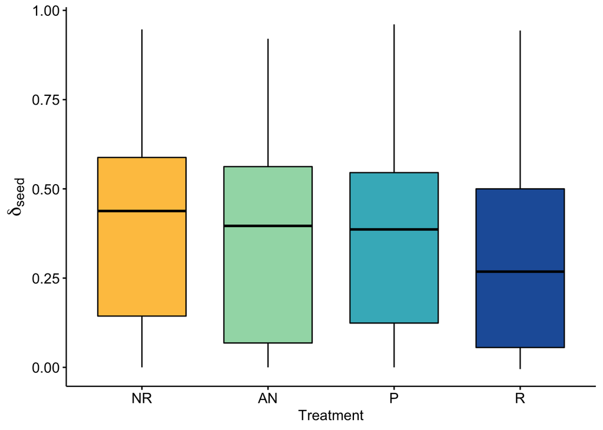

```r
# color-blind friendly color palette for plotting
CB_YlGnBu <- c("#fec44f", "#a1dab4", "#41b6c4", "#225ea8")

# plot the deltaEstablish by treatment
# no treatment differences so no compact letter display necessary
fig2A_Seed <- ggboxplot(seedLimitAnalysis_final,
                    x = "Treatment",
                    y = "deltaSeedLimitation",
                    fill = "Treatment",
                    palette =CB_YlGnBu,
                    shape = "Treatment",
                    xlab = "Treatment",
                    ylab = expression(delta["seed"]),
                    legend = "none")+
                   theme(axis.title.y =  element_text(face = "bold", size = 16))+
                   scale_x_discrete(labels = c("NR", "AN", "P", "R"))
fig2A_Seed
```

```r
#------
# Examine delta Establishment Limitation by successional stage

# make the model of delta establish and successional stage (only for early/late categories)
modSeed_succession_mixed <- lmer(deltaSeedLimitation  ~ SuccessionalStage  + (1|Species),
                                      subset(seedLimitAnalysis_final, SuccessionalStage == "Early" | SuccessionalStage == "Late"))


# check assumptions (commented out for brevity) -- assumptions met
# plot(modEstablish_succession_mixed) # residuals OK,
# qqnorm(residuals(modEstablish_succession_mixed)) #QQ plot not perfect but OK, log transform = same result so going no transform

# one-way Anova testing deltaEstablishmentLimit - no differences b/w for successional status for seed limitation
Anova(modSeed_succession_mixed, type = "II")
```

```
## Analysis of Deviance Table (Type II Wald chisquare tests)
##
## Response: deltaSeedLimitation
##                    Chisq Df Pr(>Chisq)
## SuccessionalStage 1.0055  1      0.316
```

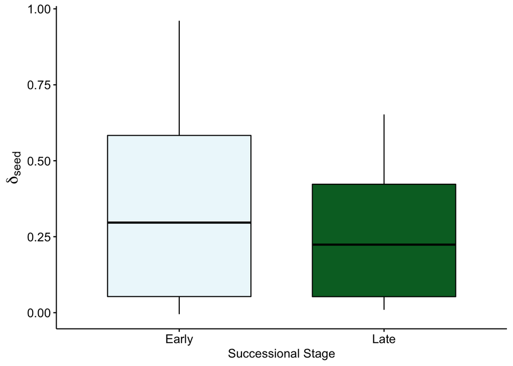

```r
# create successional stage palette
SuccStagePalette <- c( "#edf8fb", "#006d2c")

# differences between successional stage and establish limitation
# no differences with successional stage so no compact letter display necessary
fig2B_Seed <- ggboxplot(subset(seedLimitAnalysis_final, SuccessionalStage == "Early" | SuccessionalStage == "Late"),
                    x = "SuccessionalStage",
                    y = "deltaSeedLimitation",
                    fill = "SuccessionalStage",
                    palette =SuccStagePalette,
                    shape = "SuccStagePalette",
                    xlab = "Successional Stage",
                    ylab = expression(delta["seed"]),
                    legend = "none")+
                    theme(axis.title.y =  element_text(face = "bold", size = 16))
fig2B_Seed
```

```r
#-----
# Last, compare delta Establishment Limitation by seed size

# make the model of delta establish and seed size categories
modSeedSize_mixed_Seed <- lmer(deltaSeedLimitation  ~ seedSizeCat + (1|Species), seedLimitAnalysis_final)

# check assumptions (commented out for brevity) -- assumptions met
# plot(modSeedSize_mixed) # residuals OK,
# qqnorm(residuals(modSeedSize_mixed)) #QQ plot not perfect but OK, log transform = same result so going no transform

# one-way Anova testing deltaEstablishmentLimit - no differences b/w seed limitation for seed sizes
Anova(modSeedSize_mixed_Seed, type = "II")
```

```
## Analysis of Deviance Table (Type II Wald chisquare tests)
##
## Response: deltaSeedLimitation
##              Chisq Df Pr(>Chisq)
## seedSizeCat 2.2025  1     0.1378
```

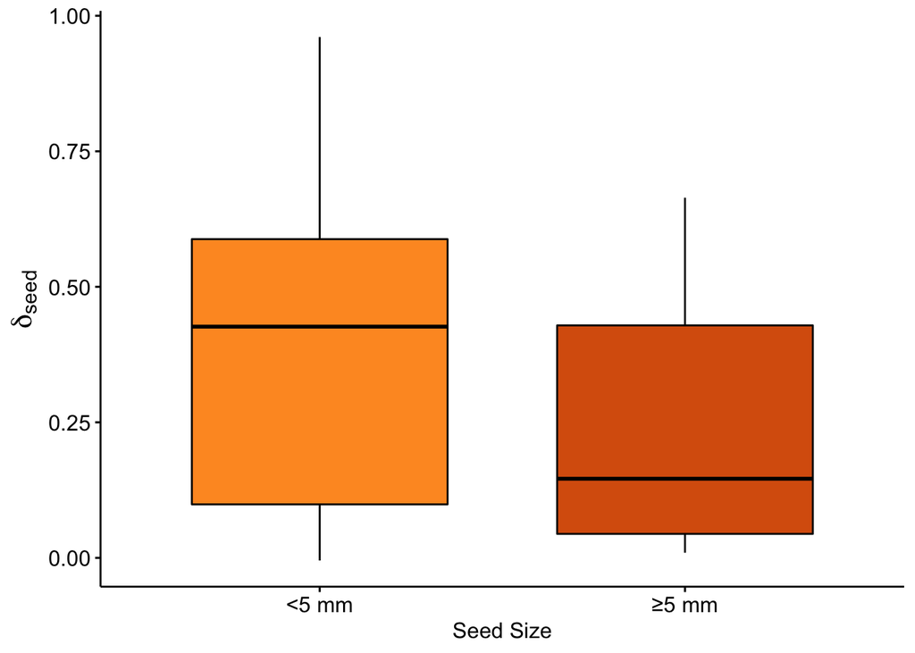

```r
# create seed size palette
SSpalette <- c("#fe9929", "#d95f0e")

# make clean seed size categories for plotting
seedLimitAnalysis_final <- seedLimitAnalysis_final %>%
                                 mutate(seedSizeCat="NA") %>%
                                 mutate(seedSizeCat = ifelse(SeedSize == "1", "<5 mm", seedSizeCat)) %>%
                                 mutate(seedSizeCat = ifelse(SeedSize == "2" |SeedSize == "3" | SeedSize == "4", "\u22655 mm", seedSizeCat))

# no differences between establish limit and seed size seed size
# no differences with seed size so no compact letter display necessary
fig2C_Seed <- ggboxplot(seedLimitAnalysis_final,
                    x = "seedSizeCat",
                    y = "deltaSeedLimitation",
                    fill = "seedSizeCat",
                    palette =SSpalette,
                    shape = "seedSizeCat",
                    xlab = "Seed Size",
                    ylab = expression(delta["seed"]),
                    legend = "none")+
                   theme(axis.title.y =  element_text(face = "bold", size = 16))
fig2C_Seed
```

## Perform establishment randomization procedure described in Appendix S2

The procedure described below compares observed to expected (randomized) establishment limitation values

### Make seed and seedling occurence matrices for each treatment on a station basis (n = 4 per site)

```r
# filter for focal species
seedsAndSeedlings_forPlotMatrixRando_filter <- seedsAndSeedlings_ByPlot_all %>%
                                                filter(Species %in% speciesList_seedlings_tenPercentSeedTreat$Species[speciesList_seedlings_tenPercentSeedTreat$Treatment == "C"]
                                                       & Treatment == "C" |
                                                       Species %in% speciesList_seedlings_tenPercentSeedTreat$Species[speciesList_seedlings_tenPercentSeedTreat$Treatment == "I"]
                                                       & Treatment == "I" |
                                                       Species %in% speciesList_seedlings_tenPercentSeedTreat$Species[speciesList_seedlings_tenPercentSeedTreat$Treatment == "P"]
                                                       & Treatment == "P" |
                                                       Species %in% speciesList_seedlings_tenPercentSeedTreat$Species[speciesList_seedlings_tenPercentSeedTreat$Treatment == "R"]
                                                       & Treatment == "R")

# don't consider stations where seedlings a are present but no seeds (perfect STS) following Muscarella et al. 2013
seedsAndSeedlings_forPlotMatrixRando_filterMus <- seedsAndSeedlings_forPlotMatrixRando_filter %>%
                                                  mutate(seedSeedling = NA) %>%
                                                  mutate(seedSeedling=ifelse(present_seeds == 1 & present_seedling == 1, count_seedling, seedSeedling))

seedsAndSeedlings_forPlotMatrixRando_pre <- dcast(seedsAndSeedlings_forPlotMatrixRando_filterMus,
                                                  Site + Treatment  + Plot ~ Species, value.var = 'seedSeedling')

# check to see if # of traps matched up for each treatment = good!
table(seedsAndSeedlings_forPlotMatrixRando_pre$Site, seedsAndSeedlings_forPlotMatrixRando_pre$Treatment)
```

```
##
##      C I P R
##   BB 4 4 4 0
##   EC 4 4 4 4
##   JG 4 4 4 4
##   MM 4 4 4 4
##   SG 4 4 4 0
```

```r
# drop unexessary columns, make NAs into zeros (plotSpeciesMatrixRando_seedlingConservativeSS)
seedsAndSeedlings_forPlotMatrixRando_final <- seedsAndSeedlings_forPlotMatrixRando_pre %>%
                                              dplyr::select(-Site, -Plot) %>% # remove unnecessary columns
                                              mutate_if(is.numeric, funs(ifelse(is.na(.), 0, .))) # make NAs zeros

# separate into treatments for separate randomizations, drop unnecessary columns, and make NAs into zeros
plotSpeciesMatrixRando_establishment_C <- seedsAndSeedlings_forPlotMatrixRando_final %>%
                                          filter(Treatment == "C") %>%
                                          dplyr::select(-Treatment)

plotSpeciesMatrixRando_establishment_I <- seedsAndSeedlings_forPlotMatrixRando_final %>%
                                          filter(Treatment == "I") %>%
                                          dplyr::select(-Treatment)

plotSpeciesMatrixRando_establishment_P <- seedsAndSeedlings_forPlotMatrixRando_final %>%
                                          filter(Treatment == "P") %>%
                                          dplyr::select(-Treatment)

plotSpeciesMatrixRando_establishment_R <- seedsAndSeedlings_forPlotMatrixRando_final %>%
                                          filter(Treatment == "R") %>%
                                          dplyr::select(-Treatment)
```

### Create the matrices you need to do establishment limitation randomizations (both abundance and occurence matrices for each treatment)

- convert all to occurrence/absence matrices for the random draws

```r
# convert to species X abundance matrices from data frames
plotSpeciesMatrix_seedling_C_abundance <- as.matrix(plotSpeciesMatrixRando_establishment_C)
plotSpeciesMatrix_seedling_I_abundance <- as.matrix(plotSpeciesMatrixRando_establishment_I)
plotSpeciesMatrix_seedling_P_abundance <- as.matrix(plotSpeciesMatrixRando_establishment_P)
plotSpeciesMatrix_seedling_R_abundance <- as.matrix(plotSpeciesMatrixRando_establishment_R)

# remove species that don't have at least 2 seedlings arriving in each treatment
plotSpeciesMatrix_seedling_C_abundance_final <- plotSpeciesMatrix_seedling_C_abundance[, !apply(is.na(plotSpeciesMatrix_seedling_C_abundance) |
                                                                                               plotSpeciesMatrix_seedling_C_abundance <= 1, 2, all)]
plotSpeciesMatrix_seedling_I_abundance_final <- plotSpeciesMatrix_seedling_I_abundance[, !apply(is.na(plotSpeciesMatrix_seedling_I_abundance) |
                                                                                               plotSpeciesMatrix_seedling_I_abundance <= 1, 2, all)]
plotSpeciesMatrix_seedling_P_abundance_final <- plotSpeciesMatrix_seedling_P_abundance[, !apply(is.na(plotSpeciesMatrix_seedling_P_abundance) |
                                                                                                plotSpeciesMatrix_seedling_P_abundance <= 1, 2, all)]
plotSpeciesMatrix_seedling_R_abundance_final <- plotSpeciesMatrix_seedling_R_abundance[, !apply(is.na(plotSpeciesMatrix_seedling_R_abundance) |
                                                                                                plotSpeciesMatrix_seedling_R_abundance <= 1, 2, all)]
plotSpeciesMatrix_seedling_C_abundance_final[20 ,"ERY_POE"] <- 3 #fix typo

# convert abundance matrix an occurrence/absence matrix for the random draws
plotSpeciesMatrix_seedling_C_occurrence <- 1*(plotSpeciesMatrix_seedling_C_abundance_final>0)
sppNames_seedling_C <- colnames(plotSpeciesMatrix_seedling_C_abundance_final)
plotSpeciesMatrix_seedling_I_occurrence <- 1*(plotSpeciesMatrix_seedling_I_abundance_final>0)
sppNames_seedling_I <- colnames(plotSpeciesMatrix_seedling_I_abundance_final)
plotSpeciesMatrix_seedling_P_occurrence <- 1*(plotSpeciesMatrix_seedling_P_abundance_final>0)
sppNames_seedling_P <- colnames(plotSpeciesMatrix_seedling_P_abundance_final)
plotSpeciesMatrix_seedling_R_occurrence <- 1*(plotSpeciesMatrix_seedling_R_abundance_final>0)
sppNames_seedling_R <- colnames(plotSpeciesMatrix_seedling_R_abundance_final)
```

### Now do randomizations for establishment limitation for each treatment X species combination

The goal here is to determine if the establishment limitation you observed in the field differs from a null model where seedlings establish according to a Poisson process across sampling stations (Norden et al. 2009). For each species the approach will be to:  
* Assume each seedlings establish randomly (and only at traps where seeds arrived too) across the sampling stations according to a Poisson process (Norden et al. 2009) and conduct this randomization 1,000 times for each species X treatment combination. * Calculate randomized establishment limitation for each species and compute 95% confidence intervals over the 1,000 iterations  
* Compare the randomized and observed establishment limitation

#### Perform the establishment limitation randomization procedure for each species X treatment combination

```r
# select n stations at random (with replacement) for each species (n = # of seeds observed for a species). Do this 1,000 times and put all the data in a list by species
# do this for treatments separately because you have different species arriving up in different treatments

# for controls (natural regeneration)
RANDO_seedling_C <- list()
for (i in 1:length(plotSpeciesMatrix_seedling_C_abundance_final[1,])){
name <- paste('item:',i,sep='')
RANDO_seedling_C[[i]] <- replicate(1000, rpois(length(plotSpeciesMatrix_seedling_C_abundance_final[,i]),
                                      sum(plotSpeciesMatrix_seedling_C_abundance_final[,i])/length(plotSpeciesMatrix_seedling_C_abundance_final[,i])))
}
names(RANDO_seedling_C) <- sppNames_seedling_C

rpois(length(plotSpeciesMatrix_seedling_C_abundance_final[,2]),
                                      sum(plotSpeciesMatrix_seedling_C_abundance_final[,2])/length(plotSpeciesMatrix_seedling_C_abundance_final[,2]))
```

```
##  [1] 0 0 0 0 0 1 0 0 0 0 0 0 1 0 1 0 0 0 0 0
```

```r
# for islands (applied nucleation)
RANDO_seedling_I <- list()
for (i in 1:length(plotSpeciesMatrix_seedling_I_abundance_final[1,])){
name <- paste('item:',i,sep='')
RANDO_seedling_I[[i]] <- replicate(1000, rpois(length(plotSpeciesMatrix_seedling_I_abundance_final[,i]),
                                      sum(plotSpeciesMatrix_seedling_I_abundance_final[,i])/length(plotSpeciesMatrix_seedling_I_abundance_final[,i])))
}
names(RANDO_seedling_I) <- sppNames_seedling_I

# for plantations
RANDO_seedling_P <- list()
for (i in 1:length(plotSpeciesMatrix_seedling_P_abundance_final[1,])){
name <- paste('item:',i,sep='')
RANDO_seedling_P[[i]] <- replicate(1000, rpois(length(plotSpeciesMatrix_seedling_P_abundance_final[,i]),
                                      sum(plotSpeciesMatrix_seedling_P_abundance_final[,i])/length(plotSpeciesMatrix_seedling_P_abundance_final[,i])))
}
names(RANDO_seedling_P) <- sppNames_seedling_P

# for references
RANDO_seedling_R <- list()
for (i in 1:length(plotSpeciesMatrix_seedling_R_abundance_final[1,])){
name <- paste('item:',i,sep='')
RANDO_seedling_R[[i]] <- replicate(1000, rpois(length(plotSpeciesMatrix_seedling_R_abundance_final[,i]),
                                      sum(plotSpeciesMatrix_seedling_R_abundance_final[,i])/length(plotSpeciesMatrix_seedling_R_abundance_final[,i])))
}
names(RANDO_seedling_R) <- sppNames_seedling_R
```

### Calculate expected (randomized) establishment limitation means and 95% CIs for each species X treatment combination

```r
##### for controls (natural regeneration)
RANDO_seedling_C_df <- melt(RANDO_seedling_C) # convert list of random samples to long df
colnames(RANDO_seedling_C_df) <- c("sample", "iteration", "numberSeedlings", "spp") # name columns

# total plots w/seeds and seedlings for calculations
totalPlotsSTS_C <- melt(plotSpeciesMatrix_seedling_C_occurrence)
totalPlotsSTS_bySpp_C <- totalPlotsSTS_C %>%
                         group_by(Var2) %>%
                         summarize(totalSTS = sum(value))
colnames(totalPlotsSTS_bySpp_C) <- c("spp", "totalSTS") # name columns

# do a bind to put those observed STS values with the randomizations
RANDO_seedling_C_df_final <- inner_join(RANDO_seedling_C_df, totalPlotsSTS_bySpp_C, by = "spp")

# calculate randomized establishment limitation for each of the 1,000 iterations by species
randomEstablishLimitation_calcs_C <- RANDO_seedling_C_df_final %>%
                                     mutate(present = ifelse(numberSeedlings>0, 1, 0)) %>%
                                     group_by(spp, iteration) %>%
                                     summarize(randomEstablishLimitation = 1-(sum(present)/(max(totalSTS)*10.67))) # scale for area

# make any negative establishment limitation = 0, this is a case where there are seedlings but no seeds
randomEstablishLimitation_calcs_C$randomEstablishLimitation[randomEstablishLimitation_calcs_C$randomEstablishLimitation < 0] <- 0


# summarize and calculate 95% CIs
randomEstablishLimitation_summary_C <- randomEstablishLimitation_calcs_C %>%
                                       group_by(spp) %>%
                                       summarize(randomEstablishLimitation_mean_C = mean(randomEstablishLimitation, na.rm = TRUE),
                                                  sd = sd(randomEstablishLimitation, na.rm = TRUE),
                                                  n = n()) %>%
                                       mutate(se = sd / sqrt(n),
                                               lower.ci = randomEstablishLimitation_mean_C - qt(1 - (0.05 / 2), n - 1) * se,
                                               upper.ci = randomEstablishLimitation_mean_C + qt(1 - (0.05 / 2), n - 1) * se)

randomEstablishLimitation_summary_C$spp <- as.factor(randomEstablishLimitation_summary_C$spp)
names(randomEstablishLimitation_summary_C)[1] <- "Species"

# now compare observed to expected establishment limitation

# get just the species you have observed seed limitation values for
seedsAndSeedlings_establish_C <- seedsAndSeedlings_all_finalSeedFilter[seedsAndSeedlings_all_finalSeedFilter$Treatment == "C",]

# combine with random seed limitation
observedRandomCompare_establishLimitation_C <- inner_join(seedsAndSeedlings_establish_C, randomEstablishLimitation_summary_C, by = "Species")
observedRandomCompare_seedlingLimitation_C_final <- observedRandomCompare_establishLimitation_C[,c("Treatment", "Species", "establishLimitation_areaScaled", "randomEstablishLimitation_mean_C", "lower.ci", "upper.ci")]

observedRandomCompare_establishLimitation_C_final <- observedRandomCompare_seedlingLimitation_C_final %>%
                                                     mutate(deltaEstablishLimitation_C =
                                                              establishLimitation_areaScaled-randomEstablishLimitation_mean_C)

#--------
##### for islands (applied nucleation)
RANDO_seedling_I_df <- melt(RANDO_seedling_I) # convert list of random samples to long df
colnames(RANDO_seedling_I_df) <- c("sample", "iteration", "numberSeedlings", "spp") # name columns

# total plots w/seeds and seedlings for calculations
totalPlotsSTS_I <- melt(plotSpeciesMatrix_seedling_I_occurrence)
totalPlotsSTS_bySpp_I <- totalPlotsSTS_I %>%
                         group_by(Var2) %>%
                         summarize(totalSTS = sum(value))
colnames(totalPlotsSTS_bySpp_I) <- c("spp", "totalSTS") # name columns

# do a bind to put those observed STS values with the randomizations
RANDO_seedling_I_df_final <- inner_join(RANDO_seedling_I_df, totalPlotsSTS_bySpp_I, by = "spp")

# calculate randomized establishment limitation for each of the 1,000 iterations by species
randomEstablishLimitation_calcs_I <- RANDO_seedling_I_df_final %>%
                                     mutate(present = ifelse(numberSeedlings>0, 1, 0)) %>%
                                     group_by(spp, iteration) %>%
                                     summarize(randomEstablishLimitation = 1-(sum(present)/(max(totalSTS)*14.665))) # scale for area

# make any negative establishment limitation = 0, this is a case where there are seedlings but no seeds
randomEstablishLimitation_calcs_I$randomEstablishLimitation[randomEstablishLimitation_calcs_I$randomEstablishLimitation < 0] <- 0

# summarize and calculate 95% CIs
randomEstablishLimitation_summary_I <- randomEstablishLimitation_calcs_I %>%
                                       group_by(spp) %>%
                                       summarize(randomEstablishLimitation_mean_I = mean(randomEstablishLimitation, na.rm = TRUE),
                                                  sd = sd(randomEstablishLimitation, na.rm = TRUE),
                                                  n = n()) %>%
                                       mutate(se = sd / sqrt(n),
                                               lower.ci = randomEstablishLimitation_mean_I - qt(1 - (0.05 / 2), n - 1) * se,
                                               upper.ci = randomEstablishLimitation_mean_I + qt(1 - (0.05 / 2), n - 1) * se)

randomEstablishLimitation_summary_I$spp <- as.factor(randomEstablishLimitation_summary_I$spp)
names(randomEstablishLimitation_summary_I)[1] <- "Species"

# now compare observed to expected establishment limitation

# get just the species you have observed seed limitation values for
seedsAndSeedlings_establish_I <- seedsAndSeedlings_all_finalSeedFilter[seedsAndSeedlings_all_finalSeedFilter$Treatment == "I",]

# combine with random seed limitation
observedRandomCompare_establishLimitation_I <- inner_join(seedsAndSeedlings_establish_I, randomEstablishLimitation_summary_I, by = "Species")
observedRandomCompare_seedlingLimitation_I_final <- observedRandomCompare_establishLimitation_I[,c("Treatment", "Species", "establishLimitation_areaScaled", "randomEstablishLimitation_mean_I", "lower.ci", "upper.ci")]
```

```r
observedRandomCompare_establishLimitation_I_final <- observedRandomCompare_seedlingLimitation_I_final %>%
                                                     mutate(deltaEstablishLimitation_I =
                                                              establishLimitation_areaScaled-randomEstablishLimitation_mean_I)


#--------
##### for plantations
RANDO_seedling_P_df <- melt(RANDO_seedling_P) # convert list of random samples to long df
colnames(RANDO_seedling_P_df) <- c("sample", "iteration", "numberSeedlings", "spp") # name columns

# total plots w/seeds and seedlings for calculations
totalPlotsSTS_P <- melt(plotSpeciesMatrix_seedling_P_occurrence)
totalPlotsSTS_bySpp_P <- totalPlotsSTS_P %>%
                         group_by(Var2) %>%
                         summarize(totalSTS = sum(value))
colnames(totalPlotsSTS_bySpp_P) <- c("spp", "totalSTS") # name columns

# do a bind to put those observed STS values with the randomizations
RANDO_seedling_P_df_final <- inner_join(RANDO_seedling_P_df, totalPlotsSTS_bySpp_P, by = "spp")

# calculate randomized establishment limitation for each of the 1,000 iterations by species
randomEstablishLimitation_calcs_P <- RANDO_seedling_P_df_final %>%
                                     mutate(present = ifelse(numberSeedlings>0, 1, 0)) %>%
                                     group_by(spp, iteration) %>%
                                     summarize(randomEstablishLimitation = 1-(sum(present)/(max(totalSTS)*10.67))) # scale for area

# make any negative establishment limitation = 0, this is a case where there are seedlings but no seeds
randomEstablishLimitation_calcs_P$randomEstablishLimitation[randomEstablishLimitation_calcs_P$randomEstablishLimitation < 0] <- 0

# summarize and calculate 95% CIs
randomEstablishLimitation_summary_P <- randomEstablishLimitation_calcs_P %>%
                                       group_by(spp) %>%
                                       summarize(randomEstablishLimitation_mean_P = mean(randomEstablishLimitation, na.rm = TRUE),
                                                  sd = sd(randomEstablishLimitation, na.rm = TRUE),
                                                  n = n()) %>%
                                       mutate(se = sd / sqrt(n),
                                               lower.ci = randomEstablishLimitation_mean_P - qt(1 - (0.05 / 2), n - 1) * se,
                                               upper.ci = randomEstablishLimitation_mean_P + qt(1 - (0.05 / 2), n - 1) * se)

randomEstablishLimitation_summary_P$spp <- as.factor(randomEstablishLimitation_summary_P$spp)
names(randomEstablishLimitation_summary_P)[1] <- "Species"

# now compare observed to expected establishment limitation

# get just the species you have observed seed limitation values for
seedsAndSeedlings_establish_P <- seedsAndSeedlings_all_finalSeedFilter[seedsAndSeedlings_all_finalSeedFilter$Treatment == "P",]

# combine with random seed limitation
observedRandomCompare_establishLimitation_P <- inner_join(seedsAndSeedlings_establish_P, randomEstablishLimitation_summary_P, by = "Species")
observedRandomCompare_seedlingLimitation_P_final <- observedRandomCompare_establishLimitation_P[,c("Treatment", "Species", "establishLimitation_areaScaled", "randomEstablishLimitation_mean_P", "lower.ci", "upper.ci")]

observedRandomCompare_establishLimitation_P_final <- observedRandomCompare_seedlingLimitation_P_final %>%
                                                     mutate(deltaEstablishLimitation_P =
                                                              establishLimitation_areaScaled-randomEstablishLimitation_mean_P)

#--------
##### for references
RANDO_seedling_R_df <- melt(RANDO_seedling_R) # convert list of random samples to long df
colnames(RANDO_seedling_R_df) <- c("sample", "iteration", "numberSeedlings", "spp") # name columns

# total plots w/seeds and seedlings for calculations
totalPlotsSTS_R <- melt(plotSpeciesMatrix_seedling_R_occurrence)
totalPlotsSTS_bySpp_R <- totalPlotsSTS_R %>%
                         group_by(Var2) %>%
                         summarize(totalSTS = sum(value))
colnames(totalPlotsSTS_bySpp_R) <- c("spp", "totalSTS") # name columns

# do a bind to put those observed STS values with the randomizations
RANDO_seedling_R_df_final <- inner_join(RANDO_seedling_R_df, totalPlotsSTS_bySpp_R, by = "spp")

# calculate randomized establishment limitation for each of the 1,000 iterations by species
randomEstablishLimitation_calcs_R <- RANDO_seedling_R_df_final %>%
                                     mutate(present = ifelse(numberSeedlings>0, 1, 0)) %>%
                                     group_by(spp, iteration) %>%
                                     summarize(randomEstablishLimitation = 1-(sum(present)/(max(totalSTS)*10.67))) # scale for area

# make any negative establishment limitation = 0, this is a case where there are seedlings but no seeds
randomEstablishLimitation_calcs_R$randomEstablishLimitation[randomEstablishLimitation_calcs_R$randomEstablishLimitation < 0] <- 0

# summarize and calculate 95% CIs
randomEstablishLimitation_summary_R <- randomEstablishLimitation_calcs_R %>%
                                       group_by(spp) %>%
                                       summarize(randomEstablishLimitation_mean_R = mean(randomEstablishLimitation, na.rm = TRUE),
                                                  sd = sd(randomEstablishLimitation, na.rm = TRUE),
                                                  n = n()) %>%
                                       mutate(se = sd / sqrt(n),
                                               lower.ci = randomEstablishLimitation_mean_R - qt(1 - (0.05 / 2), n - 1) * se,
                                               upper.ci = randomEstablishLimitation_mean_R + qt(1 - (0.05 / 2), n - 1) * se)

randomEstablishLimitation_summary_R$spp <- as.factor(randomEstablishLimitation_summary_R$spp)
names(randomEstablishLimitation_summary_R)[1] <- "Species"

# now compare observed to expected establishment limitation
```

```r
# get just the species you have observed seed limitation values for
seedsAndSeedlings_establish_R <- seedsAndSeedlings_all_finalSeedFilter[seedsAndSeedlings_all_finalSeedFilter$Treatment == "R",]

# combine with random seed limitation
observedRandomCompare_establishLimitation_R <- inner_join(seedsAndSeedlings_establish_R, randomEstablishLimitation_summary_R, by = "Species")
observedRandomCompare_seedlingLimitation_R_final <- observedRandomCompare_establishLimitation_R[,c("Treatment", "Species", "establishLimitation_areaScaled", "randomEstablishLimitation_mean_R", "lower.ci", "upper.ci")]

observedRandomCompare_establishLimitation_R_final <- observedRandomCompare_seedlingLimitation_R_final %>%
                                                     mutate(deltaEstablishLimitation_R =
                                                              establishLimitation_areaScaled-randomEstablishLimitation_mean_R)
```

### Make Table 2 which summarizes the observed and expected (from randomization) establishment limitation

```r
names(observedRandomCompare_establishLimitation_C_final)[3] <- "establishLimitation_observed_C"
names(observedRandomCompare_establishLimitation_C_final)[5] <- "lower.ci.C"
names(observedRandomCompare_establishLimitation_C_final)[6] <- "upper.ci.C"
names(observedRandomCompare_establishLimitation_C_final)[7] <- "deltaEstablishLimitation_C"
names(observedRandomCompare_establishLimitation_I_final)[3] <- "establishLimitation_observed_I"
names(observedRandomCompare_establishLimitation_I_final)[5] <- "lower.ci.I"
names(observedRandomCompare_establishLimitation_I_final)[6] <- "upper.ci.I"
names(observedRandomCompare_establishLimitation_I_final)[7] <- "deltaEstablishLimitation_I"
names(observedRandomCompare_establishLimitation_P_final)[3] <- "establishLimitation_observed_P"
names(observedRandomCompare_establishLimitation_P_final)[5] <- "lower.ci.P"
names(observedRandomCompare_establishLimitation_P_final)[6] <- "upper.ci.P"
names(observedRandomCompare_establishLimitation_P_final)[7] <- "deltaEstablishLimitation_P"
names(observedRandomCompare_establishLimitation_R_final)[3] <- "establishLimitation_observed_R"
names(observedRandomCompare_establishLimitation_R_final)[5] <- "lower.ci.R"
names(observedRandomCompare_establishLimitation_R_final)[6] <- "upper.ci.R"
names(observedRandomCompare_establishLimitation_R_final)[7] <- "deltaEstablishLimitation_R"

establishTable_a <- full_join(observedRandomCompare_establishLimitation_C_final[,c("Species", "establishLimitation_observed_C", "randomEstablishLimitation_mean_C",
                                                                                    "lower.ci.C", "upper.ci.C", "deltaEstablishLimitation_C")],
                              observedRandomCompare_establishLimitation_I_final[,c("Species", "establishLimitation_observed_I", "randomEstablishLimitation_mean_I",
                                                                                    "lower.ci.I", "upper.ci.I", "deltaEstablishLimitation_I")],
                                                                                by = "Species")

establishTable_b <- full_join(establishTable_a,
                              observedRandomCompare_establishLimitation_P_final[,c("Species", "establishLimitation_observed_P", "randomEstablishLimitation_mean_P",
                                                                                    "lower.ci.P", "upper.ci.P", "deltaEstablishLimitation_P")],
                                                                                by = "Species")

establishTable_c <- full_join(establishTable_b,
                             observedRandomCompare_establishLimitation_R_final[,c("Species", "establishLimitation_observed_R", "randomEstablishLimitation_mean_R",
                                                                                    "lower.ci.R", "upper.ci.R", "deltaEstablishLimitation_R")],
                                                                               by = "Species")

Table2 <- inner_join(establishTable_c, islasTraits, by = "Species")

# round to two digits
Table2_rounded <- Table2 %>%
                  mutate_if(is.numeric, round, digits=2)
```

### Compare delta Establishment Limitation between treatments, successional stage, and seed size

```r
establishLimit_a <-  full_join(observedRandomCompare_establishLimitation_C_final[,c("Species", "deltaEstablishLimitation_C")],
                                observedRandomCompare_establishLimitation_I_final[,c("Species", "deltaEstablishLimitation_I")],
                                by = "Species")

establishLimit_b <-  full_join(establishLimit_a,
                               observedRandomCompare_establishLimitation_P_final[,c("Species", "deltaEstablishLimitation_P")],
                               by = "Species")

establishLimit_c <-  full_join(establishLimit_b,
                               observedRandomCompare_establishLimitation_R_final[,c("Species", "deltaEstablishLimitation_R")],
                               by = "Species")

establishLimitAnalysis <- inner_join(establishLimit_c, islasTraits, by = "Species")
establishLimitAnalysis$SeedSize <- as.factor(establishLimitAnalysis$SeedSize)
establishLimitAnalysis$SuccessionalStage[establishLimitAnalysis$Species=="ERY_POE"] <- "Early" # make ERY_POE early successional

# convert to long format for analysis and plotting
establishLimitAnalysis_final <- melt(establishLimitAnalysis)
names(establishLimitAnalysis_final)[9] <- "Treatment"
names(establishLimitAnalysis_final)[10] <- "deltaEstablishmentLimitation"
establishLimitAnalysis_final$Treatment <- as.character(establishLimitAnalysis_final$Treatment)
establishLimitAnalysis_final$Treatment[establishLimitAnalysis_final$Treatment=="deltaSeedlingLimitation_C"] <- "C"
establishLimitAnalysis_final$Treatment[establishLimitAnalysis_final$Treatment=="deltaSeedlingLimitation_I"] <- "I"
establishLimitAnalysis_final$Treatment[establishLimitAnalysis_final$Treatment=="deltaSeedlingLimitation_P"] <- "P"
establishLimitAnalysis_final$Treatment[establishLimitAnalysis_final$Treatment=="deltaSeedlingLimitation_R"] <- "R"
establishLimitAnalysis_final$Treatment <- as.factor(establishLimitAnalysis_final$Treatment)
establishLimitAnalysis_final$Species <- as.factor(establishLimitAnalysis_final$Species)

# make clean seed size categories for plotting
establishLimitAnalysis_final <- establishLimitAnalysis_final %>%
                                 mutate(seedSizeCat="NA") %>%
                                 mutate(seedSizeCat = ifelse(SeedSize == "1", "<5 mm", seedSizeCat)) %>%
                                 mutate(seedSizeCat = ifelse(SeedSize == "2" |SeedSize == "3" | SeedSize == "4", "\u22655 mm", seedSizeCat))


#-----
# first examine delta Establishment Limitation by treatment

# build mixed-effects linear model of deltaEstablishmentLimitation by treatment (species ran. eff.)
modEstablish_treatment_mixed <- lmer(deltaEstablishmentLimitation ~ Treatment  + (1|Species), establishLimitAnalysis_final)
```

```
## boundary (singular) fit: see ?isSingular
```

```r
# check assumptions (commented out for brevity) -- met
# plot(modEstablish_treatment_mixed # residuals OK,
# qqnorm(residuals(modEstablish_treatment_mixed)) #QQ plot not perfect but OK, log transform = same result so going no transform

# one-way Anova testing deltaEstablishmentLimit differences b/w treatments
# no differences detected
Anova(modEstablish_treatment_mixed, type = "II")
```

```
## Analysis of Deviance Table (Type II Wald chisquare tests)
##
## Response: deltaEstablishmentLimitation
##            Chisq Df Pr(>Chisq)
## Treatment 2.5376  3     0.4685
```

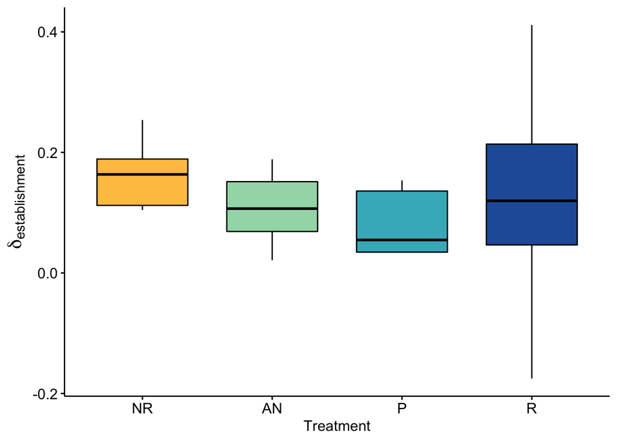

```r
# color-blind friendly color palette for plotting
CB_YlGnBu <- c("#fec44f", "#a1dab4", "#41b6c4", "#225ea8")

# plot the deltaEstablish by treatment
# no treatment differences so no compact letter display necessary
fig3A <- ggboxplot(establishLimitAnalysis_final,
                    x = "Treatment",
                    y = "deltaEstablishmentLimitation",
                    fill = "Treatment",
                    palette =CB_YlGnBu,
                    shape = "Treatment",
                    xlab = "Treatment",
                    ylab = expression(delta["establishment"]),
                    legend = "none")+
                   theme(axis.title.y =  element_text(face = "bold", size = 16))+
                   scale_x_discrete(labels = c("NR", "AN", "P", "R"))
fig3A
```

```r
#------
# Examine delta Establishment Limitation by successional stage

# make the model of delta establish and successional stage (only for early/late categories)
modEstablish_succession_mixed <- lmer(deltaEstablishmentLimitation  ~ SuccessionalStage  + (1|Species),
                                      subset(establishLimitAnalysis_final, SuccessionalStage == "Early" | SuccessionalStage == "Late"))
```

```
## boundary (singular) fit: see ?isSingular
```

```r
# check assumptions (commented out for brevity) -- assumptions met
# plot(modEstablish_succession_mixed) # residuals OK,
# qqnorm(residuals(modEstablish_succession_mixed)) #QQ plot not perfect but OK, log transform = same result so going no transform

# one-way Anova testing deltaEstablishmentLimit differences b/w successional status
Anova(modEstablish_succession_mixed, type = "II")
```

```
## Analysis of Deviance Table (Type II Wald chisquare tests)
##
## Response: deltaEstablishmentLimitation
##                    Chisq Df Pr(>Chisq)
## SuccessionalStage 6.9204  1   0.008522 **
## ---
## Signif. codes:  0 '***' 0.001 '**' 0.01 '*' 0.05 '.' 0.1 ' ' 1
```

```r
# significant ANOVA, do pairwise differences -- late much lower than early
emmeans(modEstablish_succession_mixed, pairwise ~ SuccessionalStage)
```

```
## $emmeans
##  SuccessionalStage emmean     SE    df lower.CL upper.CL
##  Early              0.152 0.0245  6.16   0.0926    0.212
##  Late               0.031 0.0405 19.90  -0.0535    0.115
##
## Degrees-of-freedom method: kenward-roger
## Confidence level used: 0.95
##
## $contrasts
##  contrast     estimate     SE   df t.ratio p.value
##  Early - Late    0.121 0.0473 17.3 2.561   0.0201
##
## Degrees-of-freedom method: kenward-roger
```